# Snowshoe hare population in Alaska: exploratory report

Leonardo Feitosa

18/11/2020

# 1. Introduction

#### This report provides an overview of the data on the snowshoe hare population from Tanana Valley, Alaska, collected between 1999 and 2012 (Kielland et al. 2017). Since snowshoe hares are an important prey item in Boreal forests, studying their population densities and long-term fluctuations is an important part of environmental monitoring. Here, the data are explored in regards to summary statistics (e. g. mean, standard deviations, and sample size) of the number of individuals sampled, their weights and their hind foot lengths. Furthermore, hypothesis tests are conducted regarding the weight difference between males and females, as well as correlation between the individual hind foot length and weight.

# 2. Data and Methods

#### The data analyzed here were retrieved from Kielland et al (2017), which consists of capture-recapture of the snowshoe hare, *Lepus americanus*, collected in Alaska between 1999 and 2012. The data used in these analyses include weight in grams, age, sex, hind foot length in millimeters, collection dates, and the collection sites. Here, I’ll compute summary statistics (mean, standard deviations, sample sizes), analyze weights between sex with a two sample t-test and Cohen’s D effect size, and use a linear model and Pearson’s correlation to explore the relationship between hind foot length and weight.

# 3. Results

## 3.1. Annual juvenile hare traps count

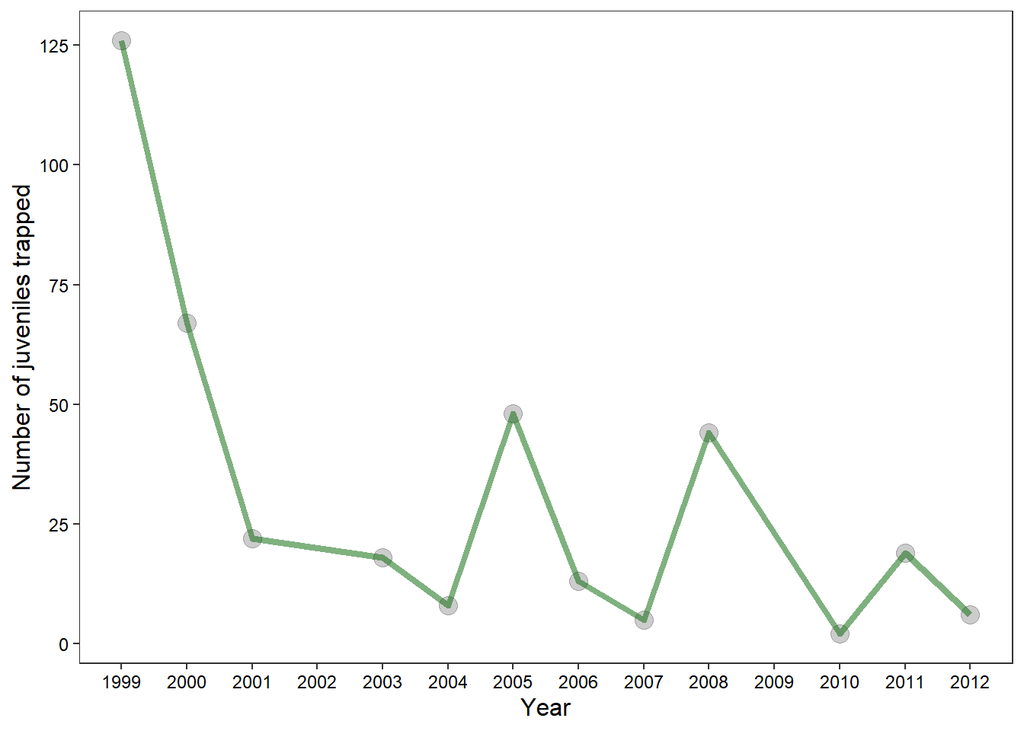

#### To standardize the data, a fixed number of traps should be used in each year and in the same locations spread out through the area. Currently, this is not the case, which adds a lot of noise to the data and decreases the quality of data interpretation and predictions. Furthermore, standardizing the number of sampling days would be key to obtain higher quality data. Despite the poor standardization, the data show a decreasing trend in juvenile hare captures. However, this trend must be taken cautiously because of the problems in data collection mentioned above.

## 3.2. Juvenile hare weights

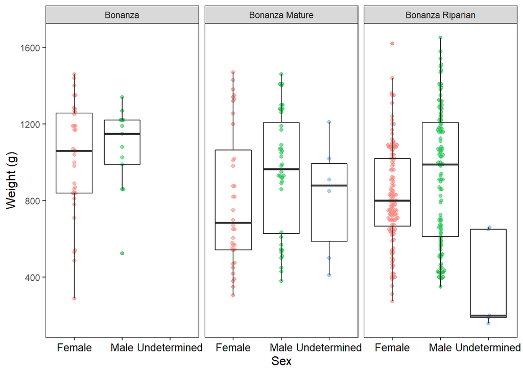

##### **Figure 2.** Weight distribution of juvenile snowshoe hare by sex. Individuals without sex determination are depicted and Undetermined. Data: Kielland et al (2017).

## 3.3. Juvenile weight comparison

**Table 1. Descriptive statistics for juvenile hare weights (g) per sex. SD = Standard Deviation, N = Sample size.**

| Sex | Mean (g) | SD (g) | N |
| --- | --- | --- | --- |
| Female | 855.3909 | 292.2526 | 200 |
| Male | 945.8589 | 333.2151 | 163 |
| Undetermined | 614.5455 | 357.5853 | 15 |

#### Based on the results of the two sample t-test, there is a 0.7% chance that the weight of males and females differs randomly. Since this chance is extremely low, we can reject the null hypothesis and conclude that there is a high chance that males and females indeed differ in weight. This is further supported by the mean values for each sex, which are highly different (945.9 for males and 855.4 for females). However, the effect size (Cohen’s D = 0.3) is evidence for a small to moderate effect, which is likely due to sample size for each sex.

## 3.4. Relationship between juvenile weight & hind foot length

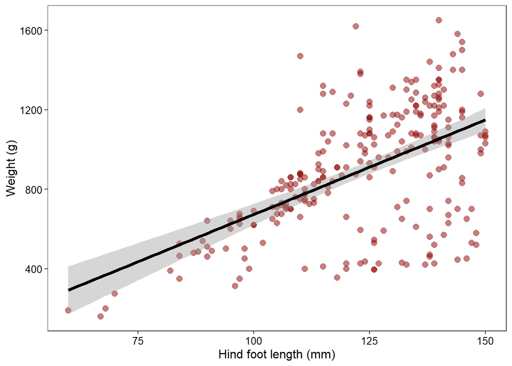

# 4. Summary

#### * Linear regression is likely not the best model to analyze this relationship given the unbalanced data spread and the little homoscedasticity.

# Citation

Kielland, K., F.S. Chapin, R.W. Ruess, and Bonanza Creek LTER. 2017. Snowshoe hare physical data in Bonanza Creek Experimental Forest: 1999-Present ver 22. Environmental Data Initiative. https://doi.org/10.6073/pasta/03dce4856d79b91557d8e6ce2cbcdc14 Metadata available at: https://portal.edirepository.org/nis/metadataviewer?packageid=knb-lter-bnz.55.22